# Forbes Celebrity Dataset

Seeing the dataset I have decided to solve the below questions

- Who has earned the highest in each year?
- In each category who has earned the highest?
- How much did Donald Trump earn in the year 2007?
- Did Ellen DeGeneres's earning increase or decrease during the years?
- In the year 2005, who all earned more than 250 Million?

# Starting with importing the data and understanding the data

```python
import pandas as pd
```

```python
import numpy as np
```

```python
import matplotlib.pyplot as plt
```

```python
data= pd.read_csv("C:\\Users\\dell\\Desktop\\forbes_celebrity_100.csv")
```

```python
data.head()
```

|  | Name | Pay (USD millions) | Year | Category |
| --- | --- | --- | --- | --- |
| 0 | Oprah Winfrey | 225.0 | 2005 | Personalities |
| 1 | Tiger Woods | 87.0 | 2005 | Athletes |
| 2 | Mel Gibson | 185.0 | 2005 | Actors |
| 3 | George Lucas | 290.0 | 2005 | Directors/Producers |
| 4 | Shaquille O'Neal | 33.4 | 2005 | Athletes |

```python
data.tail()
```

|  | Name | Pay (USD millions) | Year | Category |
| --- | --- | --- | --- | --- |
| 1542 | Calvin Harris | 38.5 | 2019 | Musicians |
| 1543 | Kendrick Lamar | 38.5 | 2019 | Musicians |
| 1544 | Brandin Cooks | 38.0 | 2019 | Athletes |
| 1545 | Shawn Mendes | 38.0 | 2019 | Musicians |
| 1546 | Celine Dion | 37.5 | 2019 | Musicians |

```python
data.columns
```

```
Index(['Name', 'Pay (USD millions)', 'Year', 'Category'], dtype='object')
```

```python
data.info()
```

```
<class 'pandas.core.frame.DataFrame'>
RangeIndex: 1547 entries, 0 to 1546
Data columns (total 4 columns):
Name                  1547 non-null object
Pay (USD millions)    1547 non-null float64
Year                  1547 non-null int64
Category              1547 non-null object
dtypes: float64(1), int64(1), object(2)
memory usage: 48.5+ KB
```

```python
data.describe()
```

|  | Pay (USD millions) | Year |
| --- | --- | --- |
| count | 1547.000000 | 1547.000000 |
| mean | 46.166839 | 2012.157725 |
| std | 38.949283 | 4.353369 |
| min | 1.500000 | 2005.000000 |
| 25% | 26.000000 | 2008.000000 |
| 50% | 39.000000 | 2012.000000 |
| 75% | 55.000000 | 2016.000000 |
| max | 620.000000 | 2019.000000 |

```python
data.isnull().sum()

#As there are no Null values, I dont need to drop any of the rows.
```

```
Name                  0
Pay (USD millions)    0
Year                  0
Category              0
dtype: int64
```

**Q1 ) Who has earned the highest in each year?**

```python
z= data[['Name','Year','Pay (USD millions)']]
```

```python
z
```

|  | Name | Year | Pay (USD millions) |
| --- | --- | --- | --- |
| 0 | Oprah Winfrey | 2005 | 225.0 |
| 1 | Tiger Woods | 2005 | 87.0 |
| 2 | Mel Gibson | 2005 | 185.0 |
| 3 | George Lucas | 2005 | 290.0 |
| 4 | Shaquille O'Neal | 2005 | 33.4 |
| ... | ... | ... | ... |
| 1542 | Calvin Harris | 2019 | 38.5 |
| 1543 | Kendrick Lamar | 2019 | 38.5 |
| 1544 | Brandin Cooks | 2019 | 38.0 |
| 1545 | Shawn Mendes | 2019 | 38.0 |
| 1546 | Celine Dion | 2019 | 37.5 |

1547 rows × 3 columns

```python
pivot1 = z.pivot_table(z, index =['Year'],
                                  aggfunc='max')
```

```python
pivot1
```

| Year | Name | Pay (USD millions) |
| --- | --- | --- |
| 2005 | Wolfgang Puck | 290.0 |
| 2006 | Wolfgang Puck | 332.0 |
| 2007 | Wolfgang Puck | 260.0 |
| 2008 | Zac Efron | 300.0 |
| 2009 | Wolfgang Puck | 275.0 |
| 2010 | Venus Williams | 315.0 |
| 2011 | Will Smith | 290.0 |
| 2012 | Zooey Deschanel | 165.0 |
| 2013 | Zooey Deschanel | 125.0 |
| 2014 | Zooey Deschanel | 620.0 |
| 2015 | Zlatan Ibrahimovic | 300.0 |
| 2016 | Zlatan Ibrahimovic | 170.0 |
| 2017 | Zlatan Ibrahimovic | 130.0 |
| 2018 | Will Smith | 285.0 |
| 2019 | Zac Brown Band | 185.0 |

**Q2 ) In each category who has earned the highest?**

```python
q2=data
q2
```

|  | Name | Pay (USD millions) | Year | Category |
| --- | --- | --- | --- | --- |
| 0 | Oprah Winfrey | 225.0 | 2005 | Personalities |
| 1 | Tiger Woods | 87.0 | 2005 | Athletes |
| 2 | Mel Gibson | 185.0 | 2005 | Actors |
| 3 | George Lucas | 290.0 | 2005 | Directors/Producers |
| 4 | Shaquille O'Neal | 33.4 | 2005 | Athletes |
| ... | ... | ... | ... | ... |
| 1542 | Calvin Harris | 38.5 | 2019 | Musicians |
| 1543 | Kendrick Lamar | 38.5 | 2019 | Musicians |
| 1544 | Brandin Cooks | 38.0 | 2019 | Athletes |
| 1545 | Shawn Mendes | 38.0 | 2019 | Musicians |
| 1546 | Celine Dion | 37.5 | 2019 | Musicians |

1547 rows × 4 columns

```python
pivot2 = q2.pivot_table(q2, index =['Category'],
                                  aggfunc='max')
```

```python
pivot2
```

| Category | Name | Pay (USD millions) | Year |
| --- | --- | --- | --- |
| Actors | Zac Efron | 239.0 | 2019 |
| Actresses | Zooey Deschanel | 56.0 | 2019 |
| Athletes | Zlatan Ibrahimovic | 300.0 | 2019 |
| Authors | Veronica Roth | 300.0 | 2019 |
| Comedians | Will Ferrell | 100.0 | 2019 |
| Directors/Producers | Tyler Perry | 332.0 | 2014 |
| Hip-hop impresario | Eminem | 39.5 | 2015 |
| Magicians | Penn & Teller | 64.0 | 2019 |
| Models | Miranda Kerr | 47.0 | 2016 |
| Musicians | Zac Brown Band | 620.0 | 2019 |
| Personalities | Wolfgang Puck | 315.0 | 2019 |
| Television actors | Ty Pennington | 52.0 | 2015 |
| Television actresses | Vanessa Williams | 43.0 | 2019 |

**Conclusion** : We can see that the **Musicians** category, people earn higher when compared to others.

**Q3 )How much did Donald Trump earn in the year 2007?**

```python
q3=data[['Name','Pay (USD millions)','Year']]
```

```python
q3.head(20)
```

|  | Name | Pay (USD millions) | Year |
| --- | --- | --- | --- |
| 0 | Oprah Winfrey | 225.0 | 2005 |
| 1 | Tiger Woods | 87.0 | 2005 |
| 2 | Mel Gibson | 185.0 | 2005 |
| 3 | George Lucas | 290.0 | 2005 |
| 4 | Shaquille O'Neal | 33.4 | 2005 |
| 5 | Steven Spielberg | 80.0 | 2005 |
| 6 | Johnny Depp | 37.0 | 2005 |
| 7 | Madonna | 50.0 | 2005 |
| 8 | Elton John | 44.0 | 2005 |
| 9 | Tom Cruise | 31.0 | 2005 |
| 10 | Brad Pitt | 25.0 | 2005 |
| 11 | Dan Brown | 76.5 | 2005 |
| 12 | Will Smith | 35.0 | 2005 |
| 13 | David Letterman | 40.0 | 2005 |
| 14 | Lance Armstrong | 28.0 | 2005 |
| 15 | Michael Jordan | 33.0 | 2005 |
| 16 | Michael Schumacher | 60.0 | 2005 |
| 17 | Will Ferrell | 40.0 | 2005 |
| 18 | Kobe Bryant | 28.8 | 2005 |
| 19 | Sean (Diddy) Combs | 36.0 | 2005 |

```python
q3.drop(q3[q3.Name !='Donald Trump'].index, inplace = True)
q3
```

|  | Name | Pay (USD millions) | Year |
| --- | --- | --- | --- |
| 121 | Donald Trump | 44.0 | 2006 |
| 218 | Donald Trump | 32.0 | 2007 |
| 344 | Donald Trump | 30.0 | 2008 |
| 421 | Donald Trump | 50.0 | 2009 |
| 532 | Donald Trump | 50.0 | 2010 |
| 616 | Donald Trump | 60.0 | 2011 |
| 713 | Donald Trump | 63.0 | 2012 |
| 829 | Donald Trump | 63.0 | 2013 |

```python
q3.drop(q3[q3.Year !=2007].index, inplace = True)
q3
```

|  | Name | Pay (USD millions) | Year |
| --- | --- | --- | --- |
| 218 | Donald Trump | 32.0 | 2007 |

**Conclusion** : Hence we see that Donald Trump had earned 32 million in 2007

**Q 4)Did Ellen DeGeneres's earning increase or decrease during the years?**

```python
q4=data[['Name','Pay (USD millions)','Year']]
q4
```

|  | Name | Pay (USD millions) | Year |
| --- | --- | --- | --- |
| 0 | Oprah Winfrey | 225.0 | 2005 |
| 1 | Tiger Woods | 87.0 | 2005 |
| 2 | Mel Gibson | 185.0 | 2005 |
| 3 | George Lucas | 290.0 | 2005 |
| 4 | Shaquille O'Neal | 33.4 | 2005 |
| ... | ... | ... | ... |
| 1542 | Calvin Harris | 38.5 | 2019 |
| 1543 | Kendrick Lamar | 38.5 | 2019 |
| 1544 | Brandin Cooks | 38.0 | 2019 |
| 1545 | Shawn Mendes | 38.0 | 2019 |
| 1546 | Celine Dion | 37.5 | 2019 |

1547 rows × 3 columns

```python
q4.drop(q4[q4.Name !='Ellen DeGeneres'].index, inplace = True)
q4
```

|  | Name | Pay (USD millions) | Year |
| --- | --- | --- | --- |
| 73 | Ellen DeGeneres | 15.0 | 2005 |
| 370 | Ellen DeGeneres | 20.0 | 2008 |
| 439 | Ellen DeGeneres | 35.0 | 2009 |
| 522 | Ellen DeGeneres | 55.0 | 2010 |
| 630 | Ellen DeGeneres | 45.0 | 2011 |
| 733 | Ellen DeGeneres | 53.0 | 2012 |
| 809 | Ellen DeGeneres | 56.0 | 2013 |
| 904 | Ellen DeGeneres | 70.0 | 2014 |
| 1008 | Ellen DeGeneres | 75.0 | 2015 |
| 1119 | Ellen DeGeneres | 75.0 | 2016 |
| 1232 | Ellen DeGeneres | 77.0 | 2017 |
| 1341 | Ellen DeGeneres | 87.5 | 2018 |
| 1458 | Ellen DeGeneres | 80.5 | 2019 |

```python
df= q4.rename(index=str,columns={"Name":"Name", "Pay (USD millions)":"Pay", "Year":"Year"})
df
```

|  | Name | Pay | Year |
| --- | --- | --- | --- |
| 73 | Ellen DeGeneres | 15.0 | 2005 |
| 370 | Ellen DeGeneres | 20.0 | 2008 |
| 439 | Ellen DeGeneres | 35.0 | 2009 |
| 522 | Ellen DeGeneres | 55.0 | 2010 |
| 630 | Ellen DeGeneres | 45.0 | 2011 |
| 733 | Ellen DeGeneres | 53.0 | 2012 |
| 809 | Ellen DeGeneres | 56.0 | 2013 |
| 904 | Ellen DeGeneres | 70.0 | 2014 |
| 1008 | Ellen DeGeneres | 75.0 | 2015 |
| 1119 | Ellen DeGeneres | 75.0 | 2016 |
| 1232 | Ellen DeGeneres | 77.0 | 2017 |
| 1341 | Ellen DeGeneres | 87.5 | 2018 |
| 1458 | Ellen DeGeneres | 80.5 | 2019 |

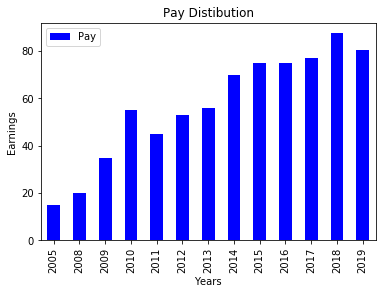

```python
#Plotting a histogram
df.plot(kind='bar',x='Year',y='Pay', color='blue')
plt.title('Pay Distibution')
plt.xlabel('Years')
plt.ylabel('Earnings')
plt.show()
```

```python
df= data.rename(index=str,columns={"Name":"Name", "Pay (USD millions)":"Pay", "Year":"Year"})
```

```python
q5=df[['Name','Pay']]
q5.head()
```

|  | Name | Pay |
| --- | --- | --- |
| 0 | Oprah Winfrey | 225.0 |
| 1 | Tiger Woods | 87.0 |
| 2 | Mel Gibson | 185.0 |
| 3 | George Lucas | 290.0 |
| 4 | Shaquille O'Neal | 33.4 |

```python
q5.drop(q5[q5.Pay < 250].index, inplace = True)
q5
```

|  | Name | Pay |
| --- | --- | --- |
| 3 | George Lucas | 290.0 |
| 100 | Steven Spielberg | 332.0 |
| 101 | Howard Stern | 302.0 |
| 200 | Oprah Winfrey | 260.0 |
| 300 | Oprah Winfrey | 275.0 |
| 308 | J.K. Rowling | 300.0 |
| 401 | Oprah Winfrey | 275.0 |
| 500 | Oprah Winfrey | 315.0 |
| 601 | Oprah Winfrey | 290.0 |
| 902 | Dr. Dre | 620.0 |
| 997 | Floyd Mayweather | 300.0 |
| 1327 | Floyd Mayweather | 285.0 |

```python
a=q5.groupby('Name').sum()
a
```

| Name | Pay |
| --- | --- |
| Dr. Dre | 620.0 |
| Floyd Mayweather | 585.0 |
| George Lucas | 290.0 |
| Howard Stern | 302.0 |
| J.K. Rowling | 300.0 |
| Oprah Winfrey | 1415.0 |
| Steven Spielberg | 332.0 |